# Time-series forecasting

```r
 needs(rmarkdown)
```

## A walk-through of model selection for univariate time-series analysis

In 2017, The New York Times did something unusual. They predicted how many people would die from drug overdoses in 2016 before the CDC released the official data. They did so with a mix of reporting and forecasting: Esimating future trends based on past data.

I know from speaking to the reporter at the Times who did the analysis how they did their forecast: They had so much data reported ahead of time, they just averaged what they just took the average increase in overdoses from the data they had and extrapolated to the places where data was missing.

Here, I take a different tact. I just use the `Forecast` package in R to generate predictions for 2018 based on half a year’s data. The CDC has released data through July, 2018. We’ll forecast to January.

```r
  needs(tidyverse)
  needs(forecast)
  needs(ggmap)

  needs(albersusa)
  needs(sf)
  needs(sp)
  needs(rgeos)
  needs(maptools)
  needs(ggplot2)
  needs(ggalt)
  needs(ggthemes)
  needs(scales)

  needs(seasonal)
  needs(vars)

  # general helpers
  source('./helpers.R')
  # annotated data cleaning
  source('./4/opioiddata.R')
```

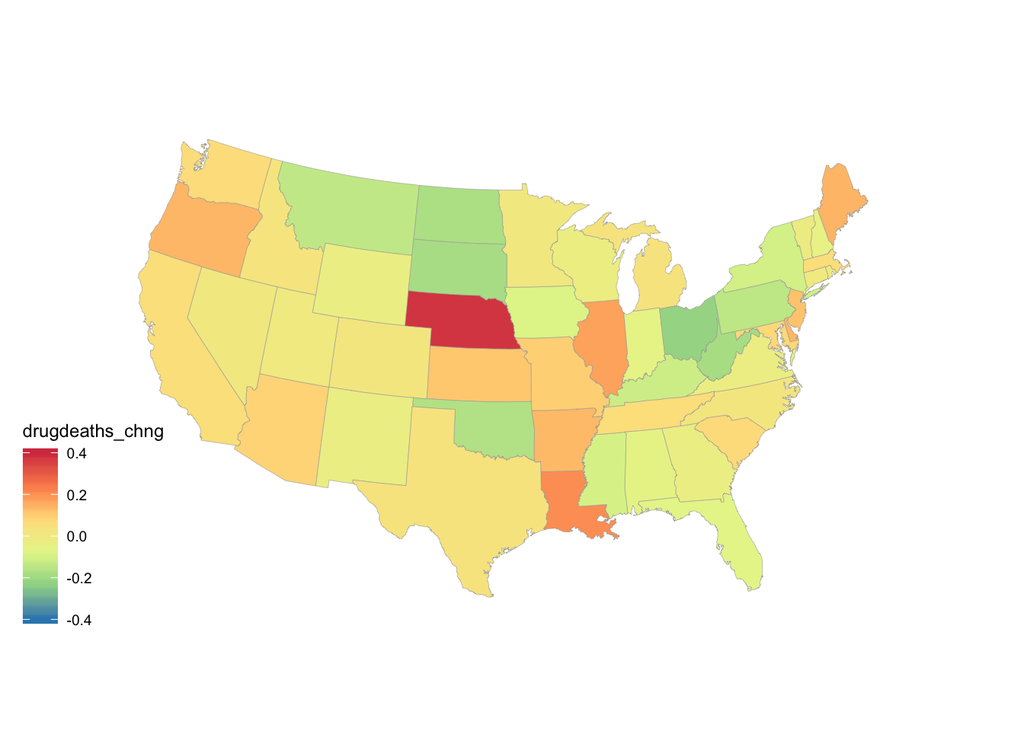

```r
  gusa <- map_data("state") %>% dplyr::select(-subregion)
  testDF1 <- df %>% filter(Year == 2017 & Month == 7) %>% filter(!is.na(region)) %>% arrange(region)
  testDF2 <- df %>% filter(Year == 2018 & Month == 7) %>% filter(!is.na(region)) %>% arrange(region)
  # get percent
  testDF2$drugdeaths_chng <- (testDF2$drugdeaths - testDF1$drugdeaths) / testDF1$drugdeaths
  gusa_pop <- left_join(testDF2, gusa, by="region")
  # plot
  ggplot(gusa_pop) +
    geom_polygon(aes(long, lat, group = group, fill = drugdeaths_chng), color = "#a6a6a6", size = 0.1) +
    coord_map("bonne", parameters=45) +
    scale_fill_distiller(palette = "Spectral", limits=c(-0.4, 0.4)) +
    ggthemes::theme_map()
```

```r
  # build time series object
  dfPreUSts <- ts(cdcdrugsUSWith18$Deaths, frequency = 12, start = c(1999, 1))
  dfPreUStsto17 <- subset(dfPreUSts, end=length(dfPreUSts) - 18)
  dfPreUStsto18 <- subset(dfPreUSts, end=length(dfPreUSts) - 6)
  # test 17 dataset
  pre17testData <- subset(dfPreUSts, start=length(dfPreUSts)-18, end=length(dfPreUSts)-6)
  # test 18 dataset
  pre18testData <- subset(dfPreUSts, start=length(dfPreUSts)-6)
```

Lookng closer, we do wee that drug overdose deaths are down slightly vs. the year prior. But we also see they’re increasing this year and a trend seems to have reversed.

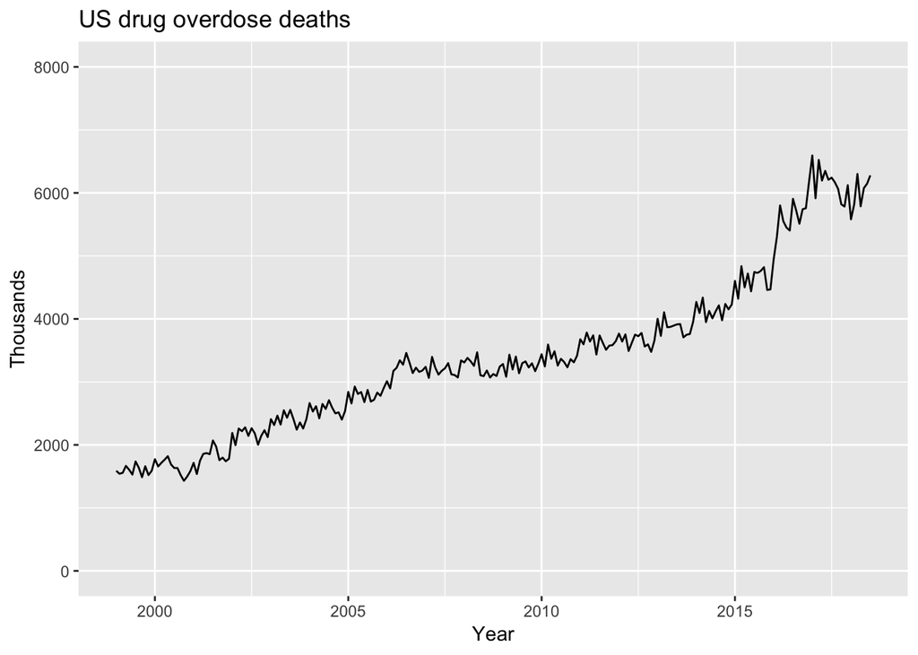

```r
  autoplot(dfPreUSts, ylim=c(0,8000)) +
  ggtitle("US drug overdose deaths") +
  xlab("Year") +
  ylab("Thousands")
```

We’ll decompose our data to remove general trend. We see a weak seasonal component and a strong trend component.

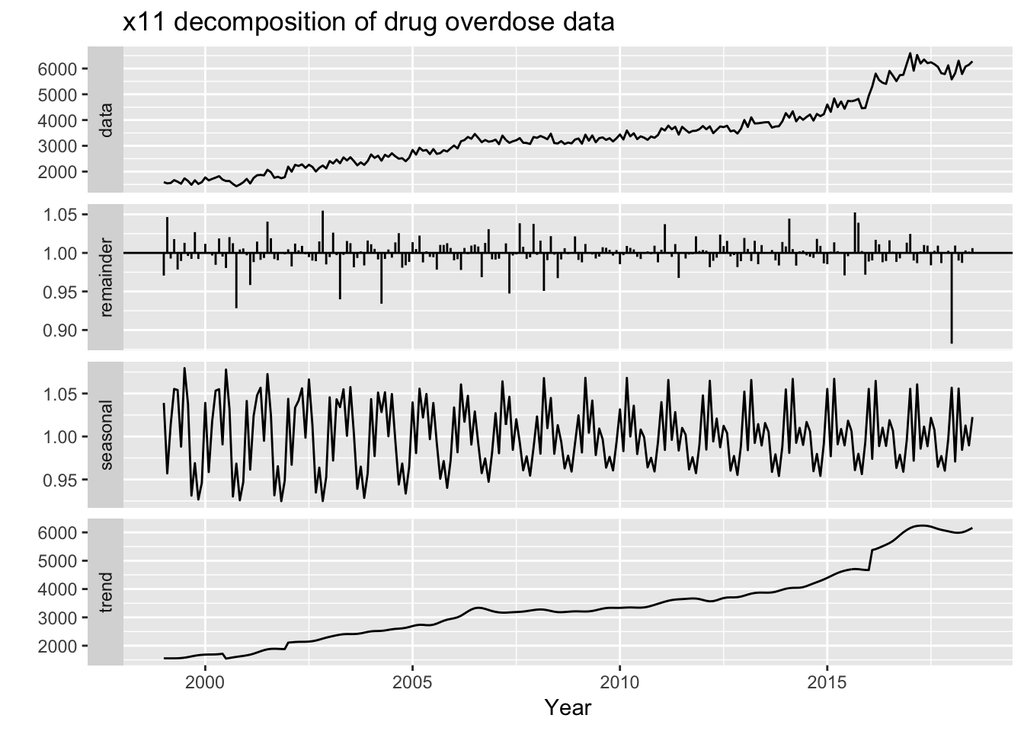

```r
  # decomposition of the data
  # can be done using the stl function and passing in the prediction method as an argument to our forecast function.
  dfPreUSts %>% seas(x11="") %>%
  autoplot() + xlab("Year") +
  ggtitle("x11 decomposition of drug overdose data")
```

```r
  #outliers test -- none found
  tsoutliers(dfPreUSts)
```

```
## $index
## integer(0)
##
## $replacements
## numeric(0)
```

They don’t seem to fit very well. We crossvalidate our models and look at the `RMSE`, `MAE`, `MPE`, `MAPE`, `MASE` on our training and test sets to gauge fit. None are fitting all that well (though the naive model fits best). We at least have a baseline from which to gauge other models. We’ll move on to trying som eothers.

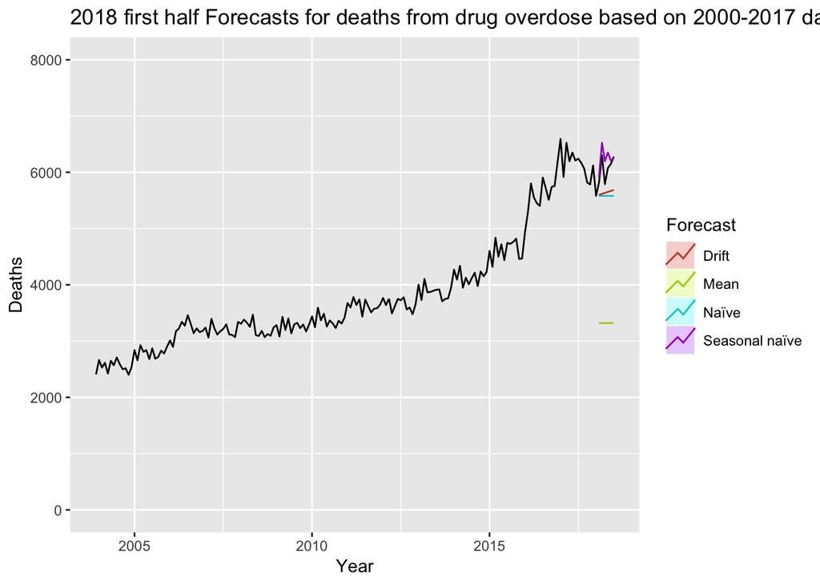

```r
  pre18fit1 <- meanf(dfPreUStsto18)
  pre18fit2 <- naive(dfPreUStsto18)
  pre18fit3 <- snaive(dfPreUStsto18)
  pre18fit4 <- rwf(dfPreUStsto18, drift=TRUE)

  autoplot(subset(dfPreUSts, start=12*5), ylim=c(0,8000)) +
  autolayer(forecast(pre18fit1, h=6),
    series="Mean", PI=FALSE) +
  autolayer(forecast(pre18fit2, h=6),
    series="Naïve", PI=FALSE) +
  autolayer(forecast(pre18fit3, h=6),
    series="Seasonal naïve", PI=FALSE) +
  autolayer(forecast(pre18fit4, h=6),
    series="Drift", PI=FALSE) +
  ggtitle("2018 first half Forecasts for deaths from drug overdose based on 2000-2017 data") +
  xlab("Year") + ylab("Deaths") +
  guides(colour=guide_legend(title="Forecast"))
```

```r
  #12-month intervals for our CV
  e1 <- tsCV(dfPreUSts, meanf)
  e2 <- tsCV(dfPreUSts, naive)
  e3 <- tsCV(dfPreUSts, snaive)
  e4 <- tsCV(dfPreUSts, rwf, drift=TRUE)

  sqrt(mean(e1^2, na.rm=TRUE))
```

```
## [1] 1281.485
```

```r
  sqrt(mean(e2^2, na.rm=TRUE))
```

```
## [1] 200.4417
```

```r
  sqrt(mean(e3^2, na.rm=TRUE))
```

```
## [1] 380.2677
```

```r
  sqrt(mean(e4^2, na.rm=TRUE))
```

```
## [1] 201.0931
```

```r
  pre18fit1 <- meanf(dfPreUStsto18)
  pre18fit2 <- naive(dfPreUStsto18)
  pre18fit3 <- snaive(dfPreUStsto18)
  pre18fit4 <- rwf(dfPreUStsto18, drift=TRUE)

  accuracy(pre18fit1, pre18testData)
```

```
##                        ME     RMSE       MAE       MPE     MAPE     MASE
## Training set 1.673033e-13 1214.176  917.4322 -14.64933 32.78053 3.236539
## Test set     2.748255e+03 2755.689 2748.2547  45.22695 45.22695 9.695360
##                    ACF1 Theil's U
## Training set  0.9750409        NA
## Test set     -0.4407441  8.114918
```

```r
  accuracy(pre18fit2, pre18testData)
```

```
##                     ME     RMSE      MAE       MPE     MAPE      MASE
## Training set  17.50877 195.8321 155.2105 0.3806673 4.835006 0.5475555
## Test set     487.33333 527.6486 487.3333 7.9273572 7.927357 1.7192264
##                    ACF1 Theil's U
## Training set -0.4740379        NA
## Test set     -0.4407441   1.65331
```

```r
  accuracy(pre18fit3, pre18testData)
```

```
##                     ME     RMSE      MAE       MPE     MAPE      MASE
## Training set  248.1797 392.7553 283.4608  6.872683 8.011204 1.0000000
## Test set     -171.1667 225.7916 183.5000 -2.864007 3.060429 0.6473558
##                   ACF1 Theil's U
## Training set 0.7834571        NA
## Test set     0.3403831  0.696836
```

```r
  accuracy(pre18fit4, pre18testData)
```

```
##                        ME     RMSE      MAE        MPE     MAPE     MASE
## Training set 9.074515e-14 195.0478 154.3158 -0.2217666 4.822464 0.544399
## Test set     4.260526e+02 465.9724 426.0526  6.9250169 6.925017 1.503039
##                    ACF1 Theil's U
## Training set -0.4740379        NA
## Test set     -0.5361954  1.460992
```

We fit a few more models, which we see do better. Holt-winters and holt modes.

```r
  e5 <- tsCV(dfPreUSts, ses)
  e6 <- tsCV(dfPreUSts, holt)
  e7 <- tsCV(dfPreUSts, holt, damped=TRUE)
  e8 <- tsCV(dfPreUSts, hw, seasonal="additive")
  # Compare RMSE:
  sqrt(mean(e5^2, na.rm=TRUE))
```

```
## [1] 181.2865
```

```r
  sqrt(mean(e6^2, na.rm=TRUE))
```

```
## [1] 181.1541
```

```r
  sqrt(mean(e7^2, na.rm=TRUE))
```

```
## [1] 181.8681
```

```r
  sqrt(mean(e8^2, na.rm=TRUE))
```

```
## [1] 147.0087
```

```r
  pre18fit5 <- ses(dfPreUStsto18, h=6)
  pre18fit6 <- holt(dfPreUStsto18, h=6)
  pre18fit7 <- holt(dfPreUStsto18, damped=TRUE, h=6)
  pre18fit8 <- hw(dfPreUStsto18, seasonal="additive", h=6)

  accuracy(pre18fit5, pre18testData)
```

```
##                     ME     RMSE      MAE       MPE     MAPE      MASE
## Training set  31.55868 176.2465 131.0787 0.7809626 4.062344 0.4624225
## Test set     307.04836 367.6927 307.0484 4.9531027 4.953103 1.0832127
##                    ACF1 Theil's U
## Training set -0.1044102        NA
## Test set     -0.4407441  1.170699
```

```r
  accuracy(pre18fit6, pre18testData)
```

```
##                       ME     RMSE      MAE       MPE     MAPE      MASE
## Training set   0.5545517 173.1227 130.8034 -0.292391 4.106043 0.4614514
## Test set     206.9340922 279.6285 228.3226  3.310578 3.680110 0.8054821
##                     ACF1 Theil's U
## Training set -0.05195782        NA
## Test set     -0.54072803 0.8948987
```

```r
  accuracy(pre18fit7, pre18testData)
```

```
##                     ME     RMSE      MAE       MPE     MAPE      MASE
## Training set  15.30605 174.6557 130.9848 0.2435659 4.080375 0.4620913
## Test set     239.18909 307.9634 251.3005 3.8385951 4.047845 0.8865439
##                     ACF1 Theil's U
## Training set -0.05968331        NA
## Test set     -0.49797865 0.9838884
```

```r
  accuracy(pre18fit8, pre18testData)
```

```
##                      ME     RMSE       MAE        MPE     MAPE      MASE
## Training set  -8.209893 129.5468  90.26049 -0.4774035 2.829304 0.3184232
## Test set     198.785491 244.9602 213.67677  3.2065050 3.463784 0.7538141
##                      ACF1 Theil's U
## Training set  0.006585462        NA
## Test set     -0.134232497 0.7656602
```

Our plots show that our fit is OK but the seasonal variation seems to be creeping in on the models without a seasonal adjustent. We also see the model is breaking down in the most recent year.

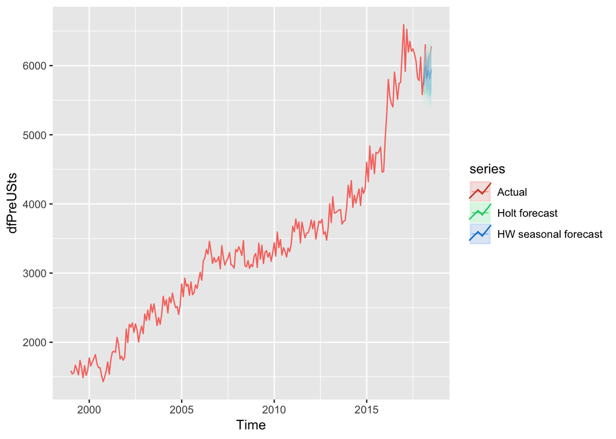

```r
  #produce predictions for rest of 2018
  # can extract values with rwf(dfPreUSts, drift=TRUE,bootstrap=TRUE, h=6)
  fith <- holt(dfPreUStsto18)
  fith2 <- hw(dfPreUStsto18, seasonal="additive", h=6)
  #
  autoplot(dfPreUSts, series="Actual") +
    autolayer(forecast(fith, h=6), ylim=c(0,8000), "Holt forecast", alpha=0.3) +
    autolayer(forecast(fith2, h=6), ylim=c(0,8000), "HW seasonal forecast", alpha=0.3)
```

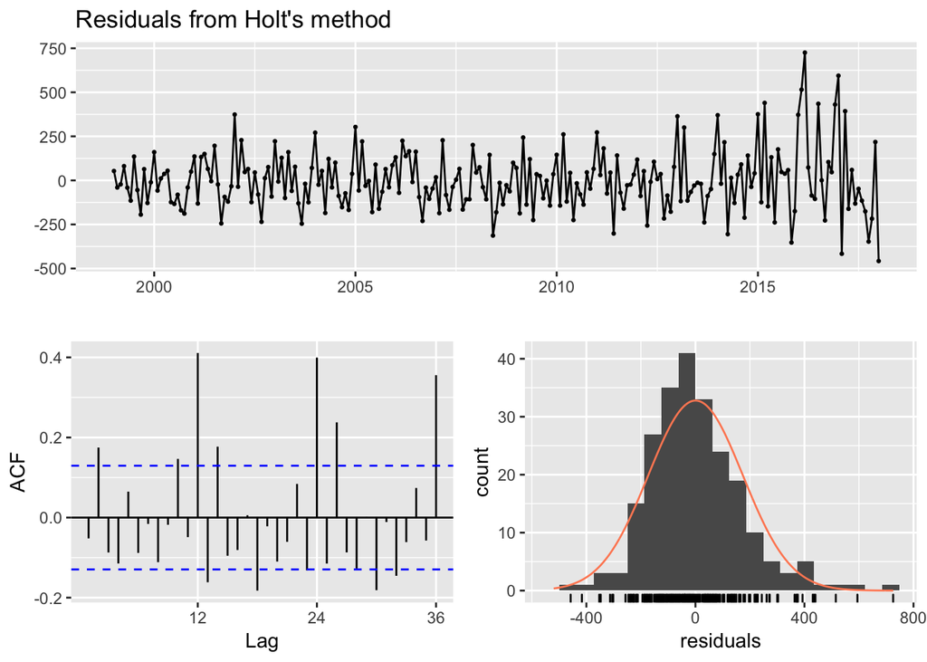

```
##
##  Ljung-Box test
##
## data:  Residuals from Holt's method
## Q* = 143.36, df = 20, p-value < 2.2e-16
##
## Model df: 4.   Total lags used: 24
```

```r
  checkresiduals(fith)
```

Next, we’ll look at ETS and ARIMA models. We see the ARIMA model does quite well. We use auto.arima to stepwise select the best combinations of *p* and *q* for the model.

```r
  # Takes 10 mins to run
  fets <- function(x, h) { stlf(x,method="ets",h=h)}
  farima <- function(x, h) { forecast(auto.arima(x), h=h) }

  e9 <- tsCV(dfPreUSts, farima)
  e10 <- tsCV(dfPreUSts, fets)

  sqrt(mean(e9^2, na.rm=TRUE))
```

```
## [1] 152.8486
```

```r
  sqrt(mean(e10^2, na.rm=TRUE))
```

```
## [1] 145.1418
```

```r
  # futurecast
  pre18fit9 <- stlf(dfPreUStsto18,method="ets")
  pre18fit10 <- auto.arima(dfPreUStsto18)

  accuracy(forecast(pre18fit9), pre18testData)
```

```
##                      ME     RMSE       MAE         MPE     MAPE      MASE
## Training set   2.937221 120.3431  82.80702 -0.07959304 2.526372 0.2921286
## Test set     191.594712 236.9141 199.20916  3.09690651 3.228462 0.7027749
##                    ACF1 Theil's U
## Training set 0.07947151        NA
## Test set     0.20431323 0.7398368
```

```r
  accuracy(forecast(pre18fit10), pre18testData)
```

```
##                    ME     RMSE       MAE       MPE     MAPE      MASE
## Training set 11.26006 145.5207 105.44834 0.2681579 3.241415 0.3720032
## Test set     15.12743 131.1430  99.96319 0.1956040 1.661293 0.3526526
##                     ACF1 Theil's U
## Training set -0.01017471        NA
## Test set     -0.07280480 0.4024959
```

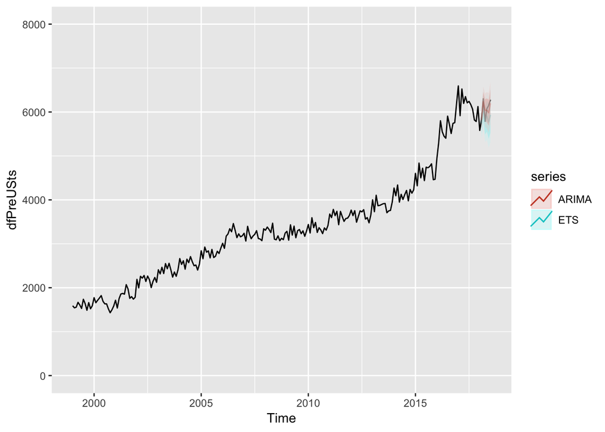

```r
  # uncomment to remove seasonality
  #seasdfPreUStsto17 <- dfPreUStsto17 %>% stl(s.window='periodic') %>% seasadj()
  #dfPreUStsto18 %>% diff() %>% ggtsdisplay(main="")

  autoplot(dfPreUSts, ylim=c(0,8000)) +
    autolayer( stlf(dfPreUStsto18,method="ets",h=6), series="ETS", alpha=0.3) +
    autolayer(forecast(pre18fit10,h=6), series="ARIMA", alpha=0.3)
```

We also try some regression models. But they don’t fit very well.

```r
  fit.drug1 <- tslm(dfPreUStsto18 ~ trend + season)
  fit.drug2 <- tslm(dfPreUStsto18 ~ trend)
  fit.drug3 <- tslm(dfPreUStsto18 ~ trend + season, lambda = 0)
  summary(fit.drug1)
```

```
##
## Call:
## tslm(formula = dfPreUStsto18 ~ trend + season)
##
## Residuals:
##     Min      1Q  Median      3Q     Max
## -635.91 -301.90   21.69  147.52 1372.61
##
## Coefficients:
##             Estimate Std. Error t value Pr(>|t|)
## (Intercept) 1441.886     98.272  14.672   <2e-16 ***
## trend         17.417      0.391  44.541   <2e-16 ***
## season2     -173.238    125.204  -1.384   0.1679
## season3       64.397    125.198   0.514   0.6075
## season4     -101.704    125.194  -0.812   0.4175
## season5      -25.279    125.191  -0.202   0.8402
## season6     -164.907    125.189  -1.317   0.1891
## season7      -41.534    125.189  -0.332   0.7404
## season8     -110.635    125.189  -0.884   0.3778
## season9     -263.158    125.191  -2.102   0.0367 *
## season10    -213.259    125.194  -1.703   0.0899 .
## season11    -292.887    125.198  -2.339   0.0202 *
## season12    -181.620    125.204  -1.451   0.1483
## ---
## Signif. codes:  0 '***' 0.001 '**' 0.01 '*' 0.05 '.' 0.1 ' ' 1
##
## Residual standard error: 390.8 on 216 degrees of freedom
## Multiple R-squared:  0.9023, Adjusted R-squared:  0.8969
## F-statistic: 166.2 on 12 and 216 DF,  p-value: < 2.2e-16
```

```r
  CV(fit.drug1)
```

```
##           CV          AIC         AICc          BIC        AdjR2
## 1.628406e+05 2.748018e+03 2.749981e+03 2.796090e+03 8.968702e-01
```

```r
  CV(fit.drug2)
```

```
##           CV          AIC         AICc          BIC        AdjR2
## 1.585647e+05 2.742809e+03 2.742916e+03 2.753110e+03 8.944019e-01
```

```r
  CV(fit.drug3)
```

```
##            CV           AIC          AICc           BIC         AdjR2
##  9.237917e-03 -1.071725e+03 -1.069762e+03 -1.023653e+03  1.000000e+00
```

```r
  #flm <- function(x, h) { forecast(tslm(x ~ trend + season, lambda=0), h=h) }

  #e11 <- tsCV(dfPreUStsto18, flm, h=6)
  #sqrt(mean(e11^2, na.rm=TRUE))
  #
  accuracy(forecast(fit.drug1), pre18testData)
```

```
##                         ME     RMSE      MAE        MPE      MAPE     MASE
## Training set -1.284913e-14 379.5187 287.2000 -0.2949316  7.915227 1.013191
## Test set      6.506871e+02 666.6951 650.6871 10.6602526 10.660253 2.295510
##                    ACF1 Theil's U
## Training set  0.9346297        NA
## Test set     -0.1413694  1.995652
```

```r
  accuracy(forecast(fit.drug3), pre18testData)
```

```
##                    ME     RMSE      MAE        MPE     MAPE      MASE
## Training set 10.63153 317.6441 261.2546 -0.4102696 7.853844 0.9216603
## Test set     82.17119 160.1462 143.4523  1.3094183 2.358776 0.5060746
##                    ACF1 Theil's U
## Training set 0.90667110        NA
## Test set     0.01130737 0.4816912
```

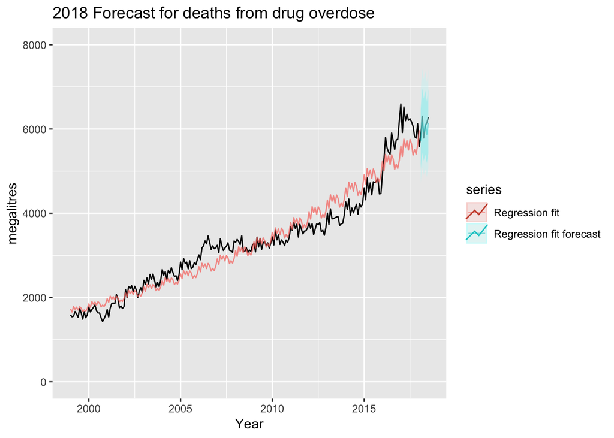

```r
  fcastRegression <- forecast(fit.drug3,h=6)
  autoplot(dfPreUSts, ylim=c(0,8000), alpha=1) +
    autolayer(fitted(fit.drug3), series="Regression fit", alpha=0.7) +
    autolayer(fcastRegression, series="Regression fit forecast", alpha=0.4) +
    ggtitle("2018 Forecast for deaths from drug overdose") +
    xlab("Year") + ylab("megalitres")
```

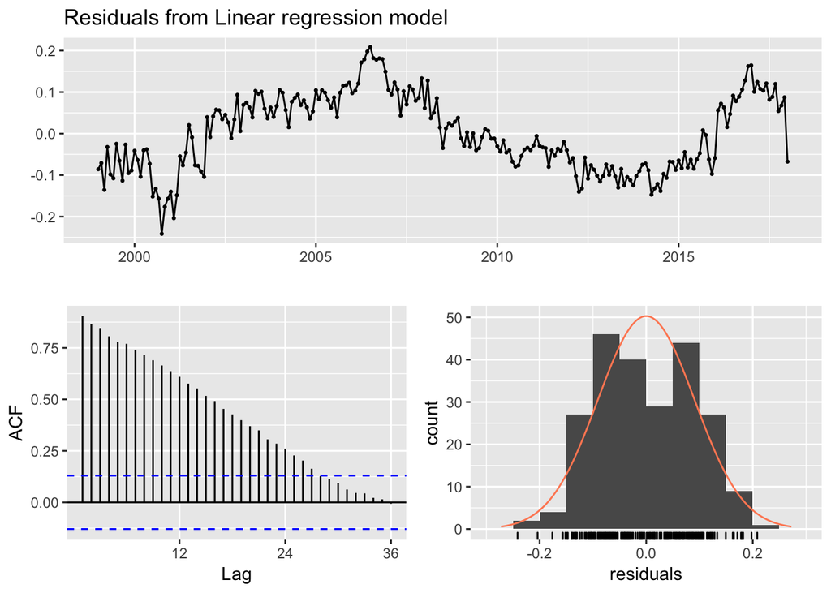

```
##
##  Breusch-Godfrey test for serial correlation of order up to 24
##
## data:  Residuals from Linear regression model
## LM test = 194.19, df = 24, p-value < 2.2e-16
```

```r
  checkresiduals(fit.drug3)
```

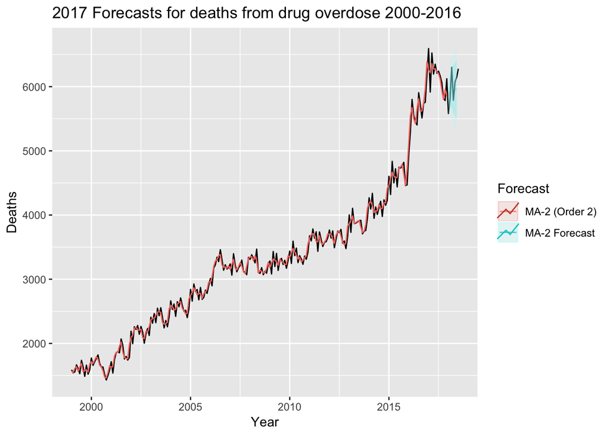

```r
  pre18fit12 <- ma(dfPreUStsto18, 2, centre=FALSE)

  autoplot(dfPreUSts) +
  autolayer(pre18fit12, series="MA-2 (Order 2)") +
  autolayer(forecast(pre18fit12, h=6), series="MA-2 Forecast", alpha=0.3) +
  ggtitle("2017 Forecasts for deaths from drug overdose 2000-2016") +
  xlab("Year") + ylab("Deaths") +
  guides(colour=guide_legend(title="Forecast"))
```

```r
  flma <- function(x, h) { forecast(ma(x, 2, centre=FALSE), h=h) }

  e12 <- tsCV(dfPreUStsto18, flma, h=6)
  sqrt(mean(e12^2, na.rm=TRUE))
```

```
## [1] 207.7878
```

```r
  accuracy(forecast(pre18fit12), pre18testData)
```

```
##                      ME      RMSE       MAE         MPE     MAPE      MASE
## Training set  0.5367545  79.79293  57.14559 -0.07669476 1.795105 0.2057121
## Test set     46.3351124 221.68426 209.53866  0.61972922 3.487656 0.7542952
##                     ACF1 Theil's U
## Training set  0.22173431        NA
## Test set     -0.06234744 0.6355154
```

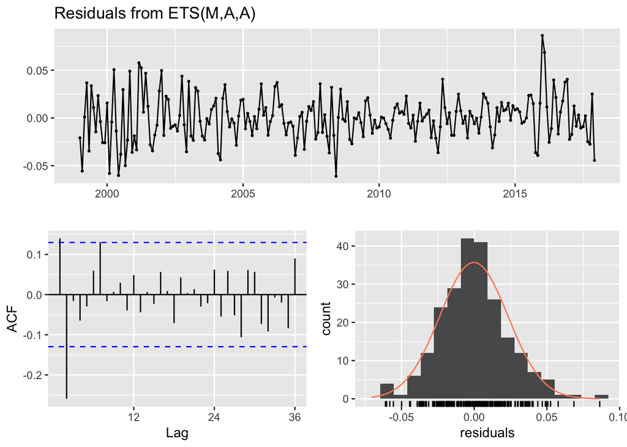

```
##
##  Ljung-Box test
##
## data:  Residuals from ETS(M,A,A)
## Q* = 32.054, df = 8, p-value = 9.107e-05
##
## Model df: 16.   Total lags used: 24
```

```r
  #
  checkresiduals(forecast(pre18fit12))
```

Likewise, splines and exponentials don’t do so well for us. We need to capture the recent trend rather than trend over the entire series, which is why the ARIMA did so well.

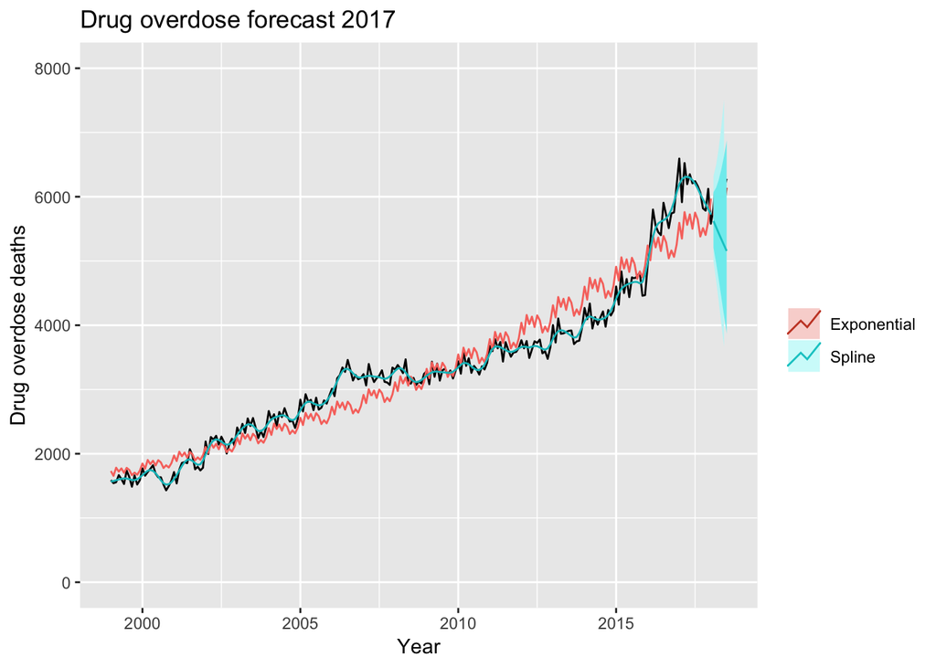

```r
  fit.exp <- tslm(dfPreUStsto18 ~ trend + season, lambda = 0)
  fcasts.exp <- forecast(fit.exp, h = 6)

  fit.spline <- splinef(dfPreUStsto18, lambda=0)
  fcasts.spline <- forecast(fit.spline, h=6)

  autoplot(dfPreUSts, ylim=c(0,8000)) +
    autolayer(fitted(fit.exp), series = "Exponential") +
    autolayer(fitted(fit.spline), series = "Spline") +
    autolayer(fcasts.exp, series="Exponential", PI=FALSE) +
    autolayer(fcasts.spline, series="Spline") +
    xlab("Year") + ylab("Drug overdose deaths") +
    ggtitle("Drug overdose forecast 2017") +
    guides(colour = guide_legend(title = " "))
```

```r
  accuracy(forecast(fit.exp), pre18testData)
```

```
##                    ME     RMSE      MAE        MPE     MAPE      MASE
## Training set 10.63153 317.6441 261.2546 -0.4102696 7.853844 0.9216603
## Test set     82.17119 160.1462 143.4523  1.3094183 2.358776 0.5060746
##                    ACF1 Theil's U
## Training set 0.90667110        NA
## Test set     0.01130737 0.4816912
```

```r
  accuracy(forecast(fit.spline), pre18testData)
```

```
##                     ME     RMSE      MAE        MPE      MAPE      MASE
## Training set  -3.72606 200.4143 153.7518 -0.2116009  4.809214 0.5424094
## Test set     681.86627 751.0314 681.8663 11.0908546 11.090855 2.4055044
##                     ACF1 Theil's U
## Training set -0.18750818        NA
## Test set      0.02484876   2.36407
```

Finally, we choose the auto.arima as our best model from `Forecast.` We bootstrap and aggregate (bag) our predictions to produce a confidence interval for our predictions. The trend line for 2018 drug overdoses we arrive at is seen below. According to our model, they continued to increase in 2018.

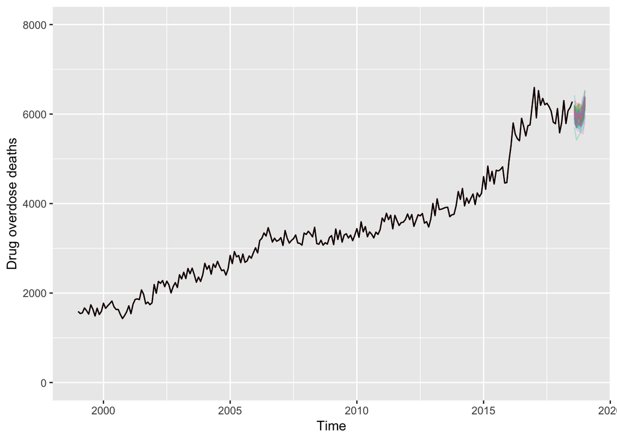

```r
  # bagged forecast with auto.arima
  # https://otexts.com/fpp2/bootstrap.html
  # takes 20 min to run

  start <- tsp(dfPreUSts)[2]+1/12

  sim <- bld.mbb.bootstrap(dfPreUSts, 100) %>%
            as.data.frame() %>%
            ts(frequency=12, start=c(1999,1))

  fc <- purrr::map(as.list(sim),
             function(x){forecast(auto.arima(x), h=6)[["mean"]]}) %>%
        as.data.frame() %>%
        ts(frequency=12, start=start)

  autoplot(dfPreUSts, ylim=c(0,8000), series="Observed data") +
    autolayer(fc, series="Forecast data", alpha=0.25) +
    autolayer(dfPreUSts, series="Observed data", colour=FALSE) +
    ylab("Drug overdose deaths")  +
    guides(colour="none")
```

A future exploration might try fitting [models in Stan](https://nwfsc-timeseries.github.io/atsa-labs/sec-stan-ar1.html) instead of the Forecast package.